# MA617HW3_b-d

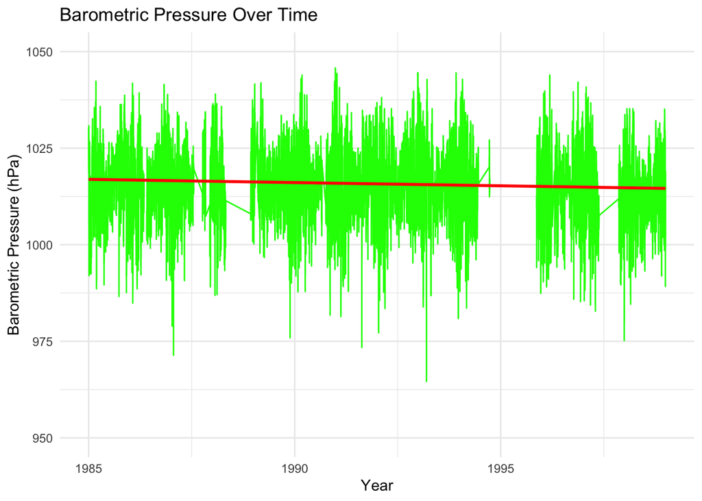

```r
# Plot Barometric Pressure over Time with zoomed-in scale
ggplot(climate_data, aes(x = Date, y = BAR)) +
  geom_line(color = "green") +
  geom_smooth(method = "lm", se = FALSE, color = "red") +  # Trend line
  labs(title = "Barometric Pressure Over Time", x = "Year", y = "Barometric Pressure (hPa)") +
  scale_y_continuous(limits = c(950, 1050)) +  # Set realistic limits for barometric pressure
  theme_minimal()
```

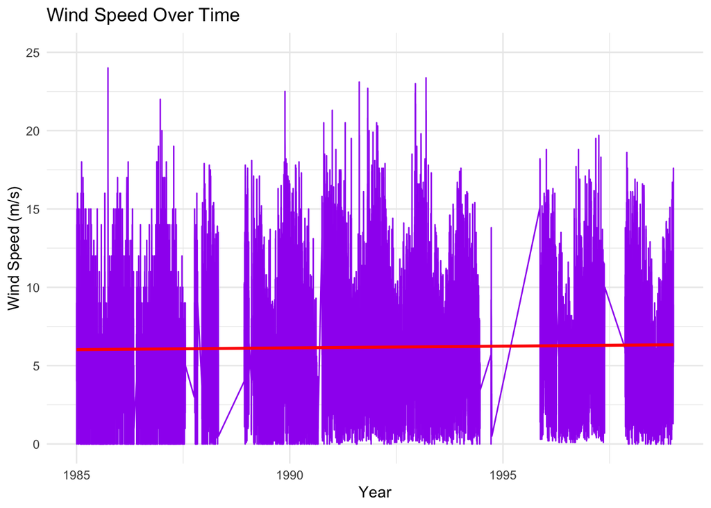

```r
# Plot Wind Speed over Time with adjusted scale
ggplot(climate_data, aes(x = Date, y = WSPD)) +
  geom_line(color = "purple") +
  geom_smooth(method = "lm", se = FALSE, color = "red") +  # Trend line
  labs(title = "Wind Speed Over Time", x = "Year", y = "Wind Speed (m/s)") +
  scale_y_continuous(limits = c(0, 25)) +  # Set realistic limits for wind speed
  theme_minimal()
```

```r
# Convert Date to a numeric format (number of days since origin)
climate_data$Date_numeric <- as.numeric(climate_data$Date)

# Fit linear models for each variable
lm_wind_speed <- lm(WSPD ~ Date_numeric, data = climate_data)
lm_wtmp <- lm(WTMP ~ Date_numeric, data = climate_data)
lm_atmp <- lm(ATMP ~ Date_numeric, data = climate_data)
lm_bar <- lm(BAR ~ Date_numeric, data = climate_data)

# Extract slopes (coefficients for Date_numeric)
slope_wind_speed <- coef(lm_wind_speed)["Date_numeric"]
slope_wtmp <- coef(lm_wtmp)["Date_numeric"]
slope_atmp <- coef(lm_atmp)["Date_numeric"]
slope_bar <- coef(lm_bar)["Date_numeric"]

# Print the slopes
cat("Slope of Atmospheric Temperature Trend:", slope_atmp, "\n")
```

```
## Slope of Atmospheric Temperature Trend: 6.327675e-05
```

```r
cat("Slope of Water Temperature Trend:", slope_wtmp, "\n")
```

```
## Slope of Water Temperature Trend: 1.308733e-05
```

```r
cat("Slope of Barometric Pressure Trend:", slope_bar, "\n")
```

```
## Slope of Barometric Pressure Trend: -0.002285527
```

```r
cat("Slope of Wind Speed Trend:", slope_wind_speed, "\n")
```

```
## Slope of Wind Speed Trend: 6.097378e-05
```

To see the effects of climate change, I used four different variables which were Atmospheric temperature, water temperature, barometric pressure, and wind speed. These were variables that I thought would represent climate changes, and hence plotted a time series plot. I also drew a trend line for each graphs to see if there were any increase or decrease in total. As you can see from the slopes, the atmospheric trend as well as water temperature and wind speed tredn tends to increase by a small amount. However, what looks like a small amount of increase can actually be a very big increase in the climate in general. Hence, I tried to divide the data into two, first half and second half, and see the differences in the mean.

```r
library(data.table)
library(ggplot2)

# Filter out rows with missing values in key climate variables
climate_data <- combined_data[, .(Date, WTMP, ATMP, BAR, WSPD)]
climate_data <- climate_data[!is.na(WTMP) & !is.na(ATMP) & !is.na(BAR) & !is.na(WSPD)]

# Ensure the date column is properly formatted
climate_data$Date <- as.Date(climate_data$Date)

# Split the data into two halves
mid_date <- climate_data$Date[round(nrow(climate_data) / 2)]

first_half <- climate_data[Date <= mid_date]
second_half <- climate_data[Date > mid_date]

# Calculate the mean for each variable in both halves
means_first_half <- first_half[, lapply(.SD, mean, na.rm = TRUE), .SDcols = c("WTMP", "ATMP", "BAR", "WSPD")]
means_second_half <- second_half[, lapply(.SD, mean, na.rm = TRUE), .SDcols = c("WTMP", "ATMP", "BAR", "WSPD")]

# Combine the results for comparison
mean_comparison <- data.table(
  Variable = c("Water Temperature (WTMP)", "Atmospheric Temperature (ATMP)", "Barometric Pressure (BAR)", "Wind Speed (WSPD)"),
  First_Half_Mean = as.numeric(means_first_half),
  Second_Half_Mean = as.numeric(means_second_half),
  Difference = as.numeric(means_second_half) - as.numeric(means_first_half)
)

# Display the comparison
print(mean_comparison)
```

```
##                          Variable First_Half_Mean Second_Half_Mean  Difference
##                            <char>           <num>            <num>       <num>
## 1:       Water Temperature (WTMP)        9.294068         8.433903 -0.86016433
## 2: Atmospheric Temperature (ATMP)        8.630688         7.680865 -0.94982312
## 3:      Barometric Pressure (BAR)     1021.091825      1015.135839 -5.95598538
## 4:              Wind Speed (WSPD)        6.164029         6.206083  0.04205404
```

As you can see from the mean, there has been some significant changes in the temperature. For both water and atmospheric temperature, there has been almost 1 degree difference. However, unlike the slope showing an increase, there has been a decrease in the temperatures. This means that the mean could have been affected by in what weather there were missing data. If there were more missing data during the summer for temperatures, the temperatures could be decreasing while the slope still tends to increase.

```r
# Load necessary libraries
library(dplyr)
# Load the rainfall dataset
rainfall_data <- read.csv("Rainfall.csv")

# Check the structure of the dataset to verify column names
str(rainfall_data)
```

```
## 'data.frame':    31714 obs. of  6 variables:
##  $ STATION         : chr  "COOP:190770" "COOP:190770" "COOP:190770" "COOP:190770" ...
##  $ STATION_NAME    : chr  "BOSTON LOGAN INTERNATIONAL AIRPORT MA US" "BOSTON LOGAN INTERNATIONAL AIRPORT MA US" "BOSTON LOGAN INTERNATIONAL AIRPORT MA US" "BOSTON LOGAN INTERNATIONAL AIRPORT MA US" ...
##  $ DATE            : chr  "19850101 01:00" "19850101 09:00" "19850101 10:00" "19850101 11:00" ...
##  $ HPCP            : num  0 0.01 0.01 0.01 0.01 0.01 0.01 0.01 0.01 0.01 ...
##  $ Measurement.Flag: chr  "g" " " " " " " ...
##  $ Quality.Flag    : logi  NA NA NA NA NA NA ...
```

```r
# Ensure the DATE column exists and is in proper format
# If DATE is in a different format, adjust the format string accordingly
rainfall_data$DATE <- as.Date(rainfall_data$DATE, format = "%Y-%m-%d")

# Summarize rainfall data: Total, Average, and Maximum Rainfall
rainfall_summary <- rainfall_data %>%
  summarise(
    Total_Rainfall = sum(HPCP, na.rm = TRUE),   # Sum of rainfall
    Average_Rainfall = mean(HPCP, na.rm = TRUE), # Average rainfall
    Max_Rainfall = max(HPCP, na.rm = TRUE)      # Maximum rainfall
  )

# Print the rainfall summary
print(rainfall_summary)
```

```
##   Total_Rainfall Average_Rainfall Max_Rainfall
## 1        1228.87        0.0387485         2.03
```

From the data frame, the data on total rainfall, average rainfall, and max rainfall is shown.

```r
# Load necessary libraries
library(dplyr)
library(ggplot2)

# Load the dataset (make sure to replace with your actual file path)
rainfall_data <- read.csv("Rainfall.csv")

# Convert DATE to proper datetime format (assuming format is YYYYMMDD HH:MM)
rainfall_data$DATE <- as.POSIXct(rainfall_data$DATE, format = "%Y%m%d %H:%M")

# Summarize the dataset to check for missing or incorrect values
summary(rainfall_data)
```

```
##    STATION          STATION_NAME            DATE
##  Length:31714       Length:31714       Min.   :1985-01-01 01:00:00.000
##  Class :character   Class :character   1st Qu.:1995-12-16 21:45:00.000
##  Mode  :character   Mode  :character   Median :2002-04-30 01:30:00.000
##                                        Mean   :2001-06-17 14:15:59.378
##                                        3rd Qu.:2008-02-12 23:15:00.000
##                                        Max.   :2013-12-31 21:00:00.000
##                                        NA's   :6
##       HPCP         Measurement.Flag   Quality.Flag
##  Min.   :0.00000   Length:31714       Mode:logical
##  1st Qu.:0.00000   Class :character   NA's:31714
##  Median :0.01000   Mode  :character
##  Mean   :0.03875
##  3rd Qu.:0.04000
##  Max.   :2.03000
##
```

```r
# Check for negative or unusually large values in the rainfall data (HPCP)
rainfall_data <- rainfall_data %>%
  filter(HPCP >= 0 & HPCP <= 500)  # Assuming rainfall should be between 0 and 500 mm

# Aggregate total rainfall by day, month, and year for analysis
rainfall_data_daily <- rainfall_data %>%
  group_by(Day = as.Date(DATE)) %>%
  summarise(Daily_Rainfall = sum(HPCP, na.rm = TRUE))

rainfall_data_monthly <- rainfall_data %>%
  group_by(Month = format(DATE, "%Y-%m")) %>%
  summarise(Monthly_Rainfall = sum(HPCP, na.rm = TRUE))

# Fix the Month format for ggplot (convert to date format with first day of the month)
rainfall_data_monthly$Month <- as.Date(paste0(rainfall_data_monthly$Month, "-01"), format = "%Y-%m-%d")

rainfall_data_yearly <- rainfall_data %>%
  group_by(Year = format(DATE, "%Y")) %>%
  summarise(Yearly_Rainfall = sum(HPCP, na.rm = TRUE))

# View the summarized data
print(head(rainfall_data_daily))
```

```
## # A tibble: 6 × 2
##   Day        Daily_Rainfall
##   <date>              <dbl>
## 1 1985-01-01           0.1
## 2 1985-01-02           0.19
## 3 1985-01-05           0.09
## 4 1985-01-07           0.03
## 5 1985-01-08           0.34
## 6 1985-01-17           0.1
```

```r
print(head(rainfall_data_monthly))
```

```
## # A tibble: 6 × 2
##   Month      Monthly_Rainfall
##   <date>                <dbl>
## 1 1985-01-01             1.12
## 2 1985-02-01             1.83
## 3 1985-03-01             2.26
## 4 1985-04-01             1.65
## 5 1985-05-01             3.36
## 6 1985-06-01             3.94
```

```r
print(head(rainfall_data_yearly))
```

```
## # A tibble: 6 × 2
##   Year  Yearly_Rainfall
##   <chr>           <dbl>
## 1 1985             36.6
## 2 1986             44.3
## 3 1987             45.2
## 4 1988             34.8
## 5 1989             42.4
## 6 1990             46.5
```

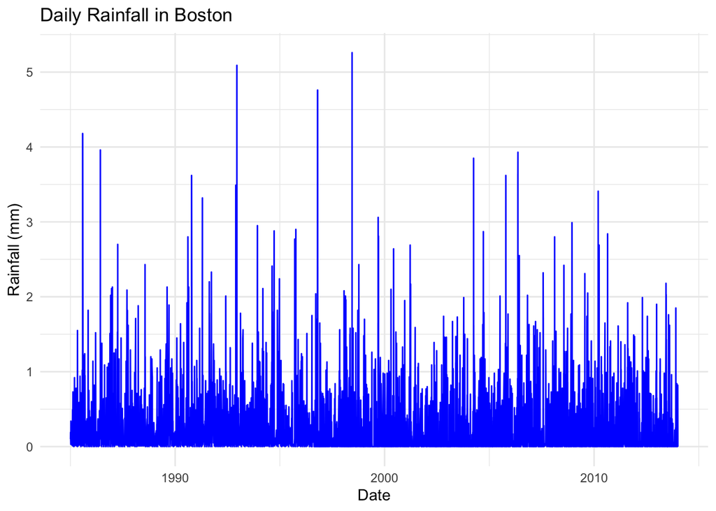

```r
# Plot rainfall patterns over time
# Daily Rainfall
ggplot(rainfall_data_daily, aes(x = Day, y = Daily_Rainfall)) +
  geom_line(color = "blue") +
  labs(title = "Daily Rainfall in Boston", x = "Date", y = "Rainfall (mm)") +
  theme_minimal()
```

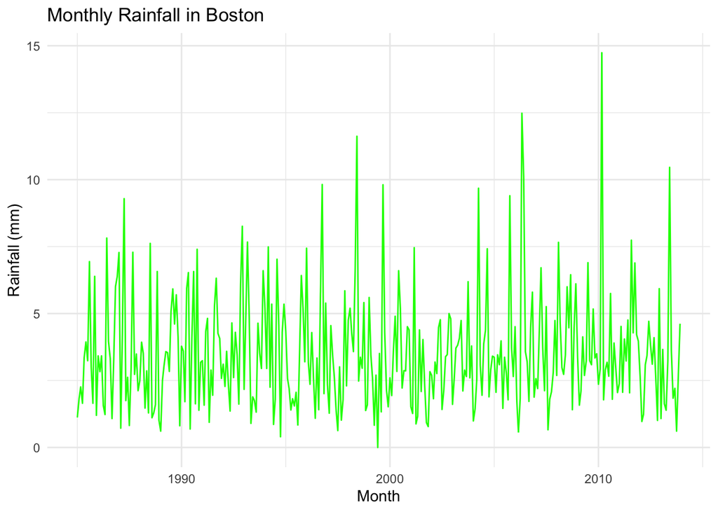

```r
# Monthly Rainfall (now with proper Date format)
ggplot(rainfall_data_monthly, aes(x = Month, y = Monthly_Rainfall)) +
  geom_line(color = "green") +
  labs(title = "Monthly Rainfall in Boston", x = "Month", y = "Rainfall (mm)") +
  theme_minimal()
```